# Research Methods in Political Science II

Day 3: Exercises

Yuki Yanai

November 19, 2016

# Preparation

```r
library('RCurl')
library('ggplot2')
library('ggmcmc')
library('GGally')
library('lattice')
library('tagcloud')
library('ellipse')
library('dplyr')
library('rstan')
library('rethinking')
rstan_options(auto_write = TRUE)
options(mc.cores = parallel::detectCores())
```

# Exercises

Exercises for Day 3. All exercises are based on [Matsuura (2016)](http://www.amazon.co.jp/dp/4320112423).

## Q1. Linear Model: Multiple Regression

```r
url <- getURL('https://raw.githubusercontent.com/MatsuuraKentaro/RStanBook/master/chap05/input/data-attendance-1.txt')
d1 <- read.csv(text = url)
glimpse(d1)
```

```
## Observations: 50
## Variables: 3
## $ A     <int> 0, 1, 0, 1, 1, 0, 0, 1, 0, 0, 1, 0, 1, 0, 0, 1, 0, 0, 0,...
## $ Score <int> 69, 145, 125, 86, 158, 133, 111, 147, 146, 145, 141, 137...
## $ Y     <dbl> 0.286, 0.196, 0.261, 0.109, 0.230, 0.350, 0.330, 0.194, ...
```

Understand the data.

```r
summary(d1)
```

```
##        A           Score             Y
##  Min.   :0.0   Min.   : 51.0   Min.   :0.0270
##  1st Qu.:0.0   1st Qu.:105.2   1st Qu.:0.1953
##  Median :0.0   Median :120.5   Median :0.2700
##  Mean   :0.4   Mean   :121.7   Mean   :0.2635
##  3rd Qu.:1.0   3rd Qu.:142.5   3rd Qu.:0.3430
##  Max.   :1.0   Max.   :185.0   Max.   :0.4230
```

```r
with(d1, table(A))
```

```
## A
##  0  1
## 30 20
```

A is a dummy variable. Make it a factor variable.

```r
d1 <- d1 %>% mutate(A = as.factor(A))
```

Check the distribution of the variables and bivariate relationships.

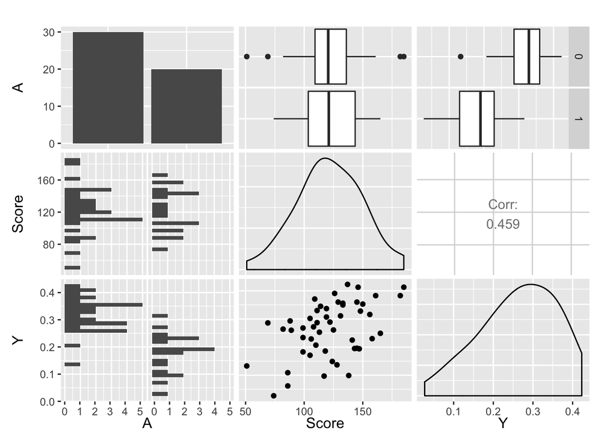

```r
ggpairs(d1)
```

A different visualiztion.

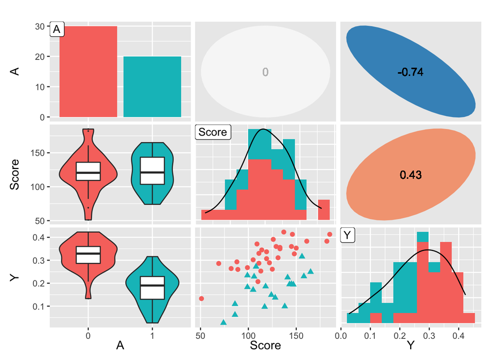

```r
n_col <- ncol(d1)
ggp <- ggpairs(d1, upper = 'blank', diag = 'blank', lower = 'blank')
# Histogram with density for each variable
for (k in 1:n_col) {
  x <- d1[, k]
  p <- ggplot(data.frame(x, A = d1$A), aes(x))
  if (class(x) == 'factor') {
    p <- p + geom_bar(aes(fill = A))
  } else {
    bw <- (max(x) - min(x))/10
    p <- p +
        geom_histogram(binwidth = bw, aes(fill = A)) +
        geom_line(eval(bquote(aes(y = ..count..*.(bw)))),
                  stat = 'density')
  }
  p <- p +
      geom_label(data = data.frame(x = -Inf, y = Inf, label = colnames(d1)[k]),
                 aes(x = x, y = y, label = label), hjust = 0, vjust = 1)
  ggp <- putPlot(ggp, p, k, k)
}

# visualize correlation by ellipse
color_at <- seq(-1, 1, length.out = 101)
for (i in 1:(n_col - 1)) {
  for (j in (i + 1):n_col) {
    x <- as.numeric(d1[,i])
    y <- as.numeric(d1[,j])
    r <- cor(x, y, method = 'spearman', use = 'pairwise.complete.obs')
    zcol <- level.colors(r, at = color_at,
                         col.regions = smoothPalette(-color_at, pal = 'RdBu'))
    textcol <- ifelse(abs(r) < 0.4, 'gray', 'black')
    ell <- ellipse(r, level = .95, type = 'l', npoints = 50,
                   scale = c(.2, .2), centre = c(.5, .5))  # "center" doesn't work!
    p <- ggplot(data.frame(ell), aes(x = x, y = y))
    p <- p + theme(
        plot.background = element_blank(),
        panel.grid.major = element_blank(),
        panel.grid.minor = element_blank(),
        panel.border = element_blank(),
        axis.ticks = element_blank()
        )
    p <- p + geom_polygon(fill = zcol, color = zcol)
    p <- p + geom_text(data = NULL, x = .5, y = .5,
                       label = round(r, 2), size = 4, col = textcol)
    ggp <- putPlot(ggp, p, i, j)
    }
}

# scatter plot or violin-and-box plots
for (j in 1:(n_col - 1)) {
  for (i in (j + 1):n_col) {
    x <- d1[,j]
    y <- d1[,i]
    p <- ggplot(data.frame(x, y, A = d1$A),
                aes(x = x, y = y, shape = A, fill = A))
    if (class(x) == 'factor') {
      p <- p + geom_violin() +
          geom_boxplot(aes(group = x), fill = 'white',
                       outlier.size = .1, width = .5)
    } else {
      p <- p + geom_point(aes(color = A), size = 2)
    }
    ggp <- putPlot(ggp, p, i, j)
  }
}
print(ggp)
```

A statistical model:
$$Y_n \sim \mbox{Normal}(\mu_n, \sigma),$$
$$\mu_n = \beta_1 + \beta_2 A_n + \beta_3 Score_n,$$
$$\beta_1 \sim \mbox{Normal}(0, 10),$$
$$\beta_2 \sim \mbox{Normal}(0, 10),$$
$$\beta_3 \sim \mbox{Normal}(0, 10),$$
$$\sigma \sim \mbox{Cauchy}^{+}(0, 20),$$
where $n = 1, 2, \dots, N$.

A Stan model:

```r
// d3-ex1.stan
data {
    int N;
    real<lower=0, upper=1> Y[N];
    int<lower=0, upper=1> A[N];
    real<lower=0, upper=1> Score[N];
}

parameters {
    real b1;
    real b2;
    real b3;
    real<lower=0> sigma;
}

transformed parameters {
    real mu[N];
    for (n in 1:N)
        mu[n] = b1 + b2*A[n] + b3*Score[n];
}

model {
    for (n in 1:N)
        Y[n] ~ normal(mu[n], sigma);
    b1 ~ normal(0, 10);
    b2 ~ normal(0, 10);
    b3 ~ normal(0, 10);
    sigma ~ cauchy(0, 20);
}

generated quantities {
    real y_pred[N];
    real log_lik[N];
    for (n in 1:N) {
        y_pred[n] = normal_rng(mu[n], sigma);
        log_lik[n] = normal_lpdf(Y[n] | mu[n], sigma);
    }
}
```

Compile the model.

```r
stan_ex1 <- stan_model('stan-models/d3-ex1.stan')
```

Sample. Scale the variable Score so that it takes values between 0 and 1.

```r
myd <- list(N = nrow(d1), Y = d1$Y,
            A = as.numeric(d1$A == '1'), Score = d1$Score/200)
fit_ex1 <- sampling(stan_ex1, data = myd, seed = 2016-11-18,
                    chains = 4, iter = 3000, warmup = 1500)
```

Check the result.

```r
print(fit_ex1)
```

```
## Inference for Stan model: d3-ex1.
## 4 chains, each with iter=3000; warmup=1500; thin=1;
## post-warmup draws per chain=1500, total post-warmup draws=6000.
##
##               mean se_mean   sd   2.5%    25%    50%    75%  97.5% n_eff
## b1            0.12    0.00 0.03   0.06   0.10   0.12   0.14   0.19  2072
## b2           -0.14    0.00 0.01  -0.17  -0.15  -0.14  -0.13  -0.12  3691
## b3            0.32    0.00 0.05   0.22   0.29   0.33   0.36   0.42  2025
## sigma         0.05    0.00 0.01   0.04   0.05   0.05   0.06   0.06  2776
## mu[1]         0.24    0.00 0.02   0.20   0.22   0.24   0.25   0.27  2639
## mu[2]         0.22    0.00 0.01   0.19   0.21   0.22   0.22   0.24  3943
## mu[3]         0.33    0.00 0.01   0.31   0.32   0.33   0.33   0.34  4680
## mu[4]         0.12    0.00 0.01   0.09   0.11   0.12   0.13   0.15  3104
## mu[5]         0.24    0.00 0.01   0.21   0.23   0.24   0.25   0.27  3436
## mu[6]         0.34    0.00 0.01   0.32   0.33   0.34   0.35   0.36  4423
## mu[7]         0.30    0.00 0.01   0.28   0.30   0.30   0.31   0.32  4200
## mu[8]         0.22    0.00 0.01   0.19   0.21   0.22   0.23   0.24  3857
## mu[9]         0.36    0.00 0.01   0.34   0.35   0.36   0.37   0.38  3722
## mu[10]        0.36    0.00 0.01   0.34   0.35   0.36   0.37   0.38  3772
## mu[11]        0.21    0.00 0.01   0.18   0.20   0.21   0.22   0.23  4199
## mu[12]        0.35    0.00 0.01   0.33   0.34   0.35   0.35   0.37  4210
## mu[13]        0.17    0.00 0.01   0.15   0.16   0.17   0.18   0.19  4531
## mu[14]        0.30    0.00 0.01   0.28   0.30   0.30   0.31   0.32  4200
## mu[15]        0.30    0.00 0.01   0.28   0.29   0.30   0.31   0.32  4074
## mu[16]        0.14    0.00 0.01   0.12   0.13   0.14   0.15   0.17  3673
## mu[17]        0.31    0.00 0.01   0.29   0.30   0.31   0.32   0.33  4378
## mu[18]        0.26    0.00 0.01   0.23   0.25   0.26   0.27   0.28  2887
## mu[19]        0.42    0.00 0.02   0.39   0.41   0.42   0.44   0.46  2699
## mu[20]        0.23    0.00 0.01   0.20   0.22   0.23   0.24   0.26  3507
## mu[21]        0.12    0.00 0.01   0.09   0.11   0.12   0.13   0.15  3104
## mu[22]        0.16    0.00 0.01   0.13   0.15   0.16   0.16   0.18  4095
## mu[23]        0.15    0.00 0.01   0.13   0.14   0.15   0.16   0.18  3999
## mu[24]        0.21    0.00 0.01   0.19   0.20   0.21   0.22   0.24  4125
## mu[25]        0.17    0.00 0.01   0.15   0.16   0.17   0.18   0.19  4508
## mu[26]        0.19    0.00 0.01   0.17   0.18   0.19   0.20   0.21  4568
## mu[27]        0.32    0.00 0.01   0.30   0.31   0.32   0.32   0.33  4606
## mu[28]        0.32    0.00 0.01   0.30   0.31   0.32   0.32   0.33  4606
## mu[29]        0.38    0.00 0.01   0.36   0.38   0.38   0.39   0.41  3156
## mu[30]        0.31    0.00 0.01   0.29   0.30   0.31   0.31   0.33  4321
## mu[31]        0.25    0.00 0.02   0.22   0.24   0.25   0.26   0.28  3226
```

[output cut: 266 more lines]

```
## log_lik[42]    1
## log_lik[43]    1
## log_lik[44]    1
## log_lik[45]    1
## log_lik[46]    1
## log_lik[47]    1
## log_lik[48]    1
## log_lik[49]    1
## log_lik[50]    1
## lp__           1
##
## Samples were drawn using NUTS(diag_e) at Tue Nov 22 15:05:39 2016.
## For each parameter, n_eff is a crude measure of effective sample size,
## and Rhat is the potential scale reduction factor on split chains (at
## convergence, Rhat=1).
```

Check the convergence visually.

```r
ggmcmc(ggs(fit_ex1, inc_warmup = TRUE), plot = 'traceplot',
       file = 'output/d3-ex1-traceplots.pdf')
```

```
## Plotting traceplots
```

```
## Time taken to generate the report: 37 seconds.
```

Plot the effects.

```
## ci_level: 0.8 (80% intervals)
```

```
## outer_level: 0.95 (95% intervals)
```

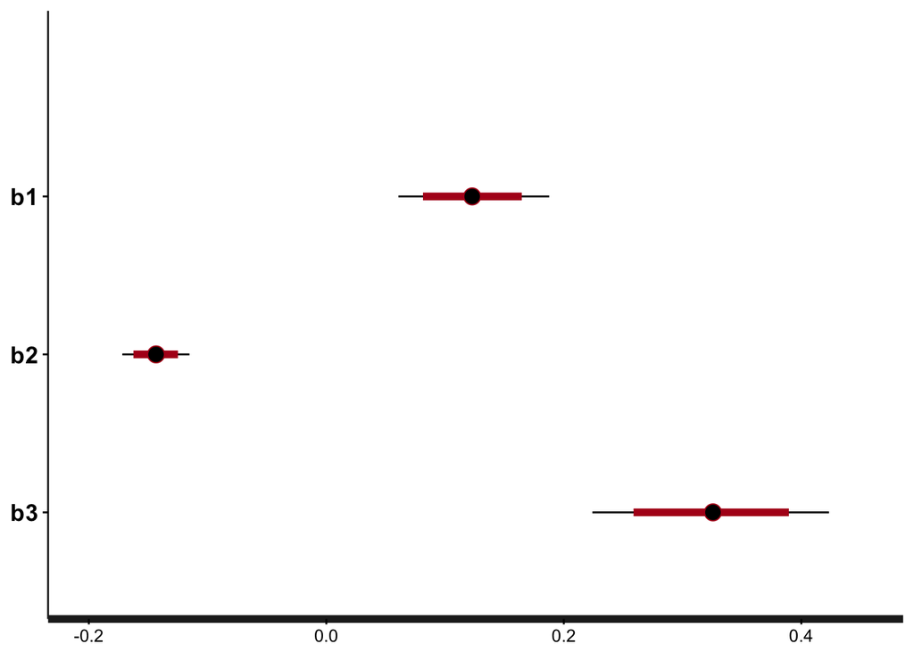

```r
plot(fit_ex1, pars = c('b1', 'b2', 'b3'))
```

Alternatively, with **rethinking** loaded,

```
## 150 vector or matrix parameters omitted in display. Use depth=2 to show them.
```

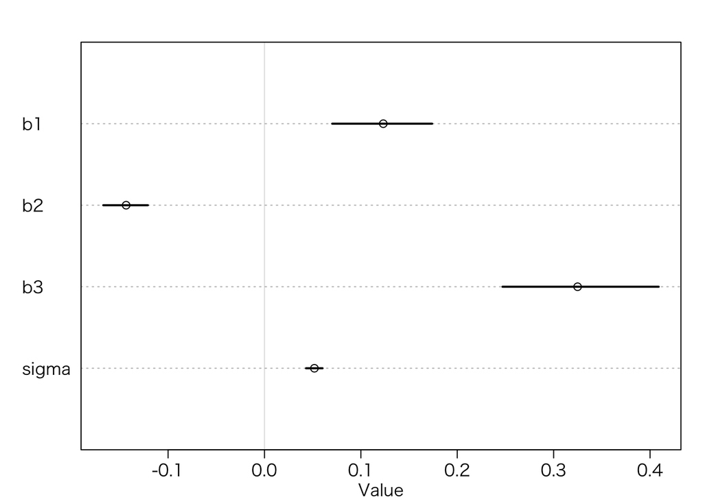

```r
plot(precis(fit_ex1))
```

A vectorized Stan model.

```r
// d3-ex1b.stan
data {
    int N;
    vector<lower=0, upper=1>[N] Y;
    vector<lower=0, upper=1>[N] A;
    vector<lower=0, upper=1>[N] Score;
}

parameters {
    vector[3] b;
    real<lower=0> sigma;
}

transformed parameters {
    vector[N] mu;
    mu = b[1] + b[2]*A + b[3]*Score;
}

model {
    Y ~ normal(mu, sigma);
    b ~ normal(0, 10);
    sigma ~ cauchy(0, 20);
}

generated quantities {
    real y_pred[N];
    real error[N];
    real log_lik[N];
    for (n in 1:N) {
        y_pred[n] = normal_rng(mu[n], sigma);
        error[n] = Y[n] - mu[n];
        log_lik[n] = normal_lpdf(Y[n] | mu[n], sigma);
    }
}
```

```r
stan_ex1b <- stan_model('stan-models/d3-ex1b.stan')
```

Sample.

```r
fit_ex1b <- sampling(stan_ex1b, data = myd, seed = 9999,
                     chains = 4, iter = 3000, warmup = 1500)
```

```r
print(fit_ex1b)
```

```
## Inference for Stan model: d3-ex1b.
## 4 chains, each with iter=3000; warmup=1500; thin=1;
## post-warmup draws per chain=1500, total post-warmup draws=6000.
##
##               mean se_mean   sd   2.5%    25%    50%    75%  97.5% n_eff
## b[1]          0.12    0.00 0.03   0.06   0.10   0.12   0.15   0.19  1781
## b[2]         -0.14    0.00 0.01  -0.17  -0.15  -0.14  -0.13  -0.12  3649
## b[3]          0.32    0.00 0.05   0.22   0.29   0.32   0.36   0.42  1819
## sigma         0.05    0.00 0.01   0.04   0.05   0.05   0.05   0.06  3312
## mu[1]         0.24    0.00 0.02   0.21   0.23   0.24   0.25   0.27  2183
## mu[2]         0.21    0.00 0.01   0.19   0.21   0.21   0.22   0.24  3644
## mu[3]         0.33    0.00 0.01   0.31   0.32   0.33   0.33   0.34  5215
## mu[4]         0.12    0.00 0.01   0.09   0.11   0.12   0.13   0.15  3501
## mu[5]         0.24    0.00 0.01   0.21   0.23   0.24   0.25   0.26  2843
## mu[6]         0.34    0.00 0.01   0.32   0.33   0.34   0.35   0.36  5173
## mu[7]         0.30    0.00 0.01   0.29   0.30   0.30   0.31   0.32  4241
## mu[8]         0.22    0.00 0.01   0.19   0.21   0.22   0.23   0.24  3548
## mu[9]         0.36    0.00 0.01   0.34   0.35   0.36   0.37   0.38  4478
## mu[10]        0.36    0.00 0.01   0.34   0.35   0.36   0.37   0.38  4550
## mu[11]        0.21    0.00 0.01   0.19   0.20   0.21   0.22   0.23  3853
## mu[12]        0.35    0.00 0.01   0.33   0.34   0.35   0.35   0.37  5011
## mu[13]        0.17    0.00 0.01   0.15   0.16   0.17   0.18   0.19  4752
## mu[14]        0.30    0.00 0.01   0.29   0.30   0.30   0.31   0.32  4241
## mu[15]        0.30    0.00 0.01   0.28   0.29   0.30   0.31   0.32  4075
## mu[16]        0.14    0.00 0.01   0.12   0.13   0.14   0.15   0.16  4086
## mu[17]        0.31    0.00 0.01   0.29   0.30   0.31   0.31   0.33  4500
## mu[18]        0.26    0.00 0.01   0.23   0.25   0.26   0.27   0.28  2371
## mu[19]        0.42    0.00 0.02   0.39   0.41   0.42   0.44   0.46  2942
## mu[20]        0.23    0.00 0.01   0.20   0.22   0.23   0.24   0.26  3125
## mu[21]        0.12    0.00 0.01   0.09   0.11   0.12   0.13   0.15  3501
## mu[22]        0.15    0.00 0.01   0.13   0.15   0.15   0.16   0.18  4489
## mu[23]        0.15    0.00 0.01   0.13   0.14   0.15   0.16   0.17  4405
## mu[24]        0.21    0.00 0.01   0.19   0.20   0.21   0.22   0.24  3746
## mu[25]        0.17    0.00 0.01   0.15   0.16   0.17   0.18   0.19  4741
## mu[26]        0.19    0.00 0.01   0.17   0.18   0.19   0.19   0.21  4609
## mu[27]        0.32    0.00 0.01   0.30   0.31   0.32   0.32   0.33  4915
## mu[28]        0.32    0.00 0.01   0.30   0.31   0.32   0.32   0.33  4915
## mu[29]        0.38    0.00 0.01   0.36   0.38   0.38   0.39   0.41  3604
## mu[30]        0.31    0.00 0.01   0.29   0.30   0.31   0.31   0.33  4413
## mu[31]        0.25    0.00 0.02   0.22   0.24   0.25   0.26   0.28  2255
```

[output cut: 366 more lines]

```
## log_lik[42]    1
## log_lik[43]    1
## log_lik[44]    1
## log_lik[45]    1
## log_lik[46]    1
## log_lik[47]    1
## log_lik[48]    1
## log_lik[49]    1
## log_lik[50]    1
## lp__           1
##
## Samples were drawn using NUTS(diag_e) at Tue Nov 22 15:06:25 2016.
## For each parameter, n_eff is a crude measure of effective sample size,
## and Rhat is the potential scale reduction factor on split chains (at
## convergence, Rhat=1).
```

```
## ci_level: 0.8 (80% intervals)
```

```
## outer_level: 0.95 (95% intervals)
```

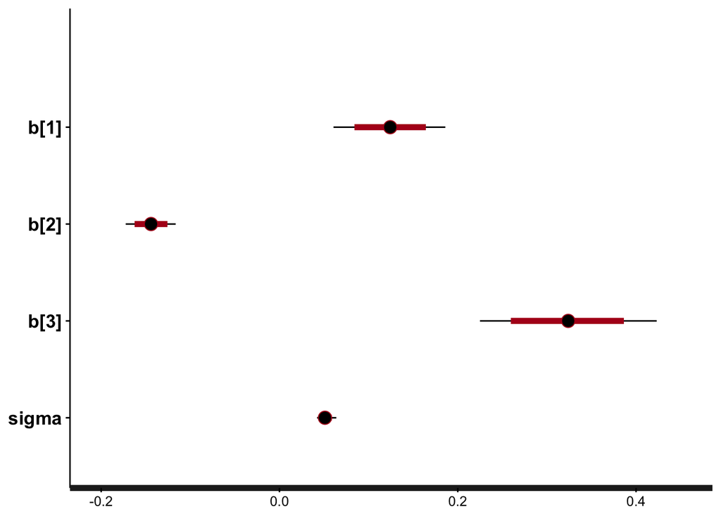

```r
plot(fit_ex1b, pars = c('b', 'sigma'))
```

Alternatively,

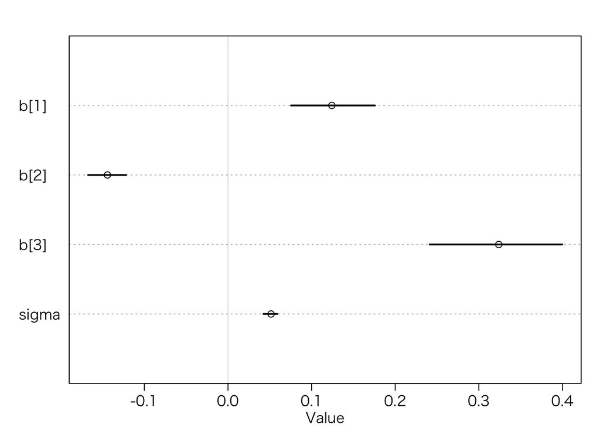

```r
plot(precis(fit_ex1b, depth = 2, pars = c('b', 'sigma')))
```

Interpret the result.

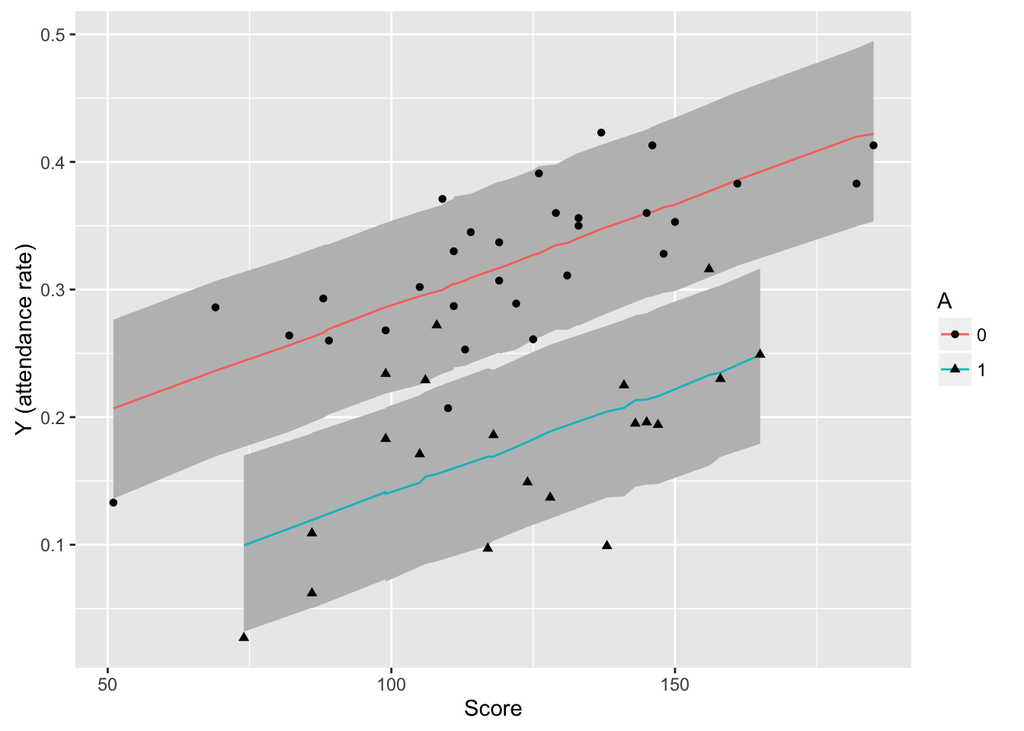

```r
mcsample <- rstan::extract(fit_ex1b)
# 10h, 50th, and 90th percentiles of predicted values
d_quant <- data.frame(p10 = apply(mcsample$y_pred, 2, quantile, .1),
                      p50 = apply(mcsample$y_pred, 2, quantile, .5),
                      p90 = apply(mcsample$y_pred, 2, quantile, .9))
d1 <- bind_cols(d1, d_quant)

p1 <- ggplot(d1, aes(x = Score, shape = A)) +
    geom_ribbon(aes(ymin = p10, ymax = p90), fill = 'gray') +
    geom_line(aes(y = p50, color = A)) +
    geom_point(aes(y = Y)) +
    ylab('Y (attendance rate)')
print(p1)
```

Predicted vs. Observed.

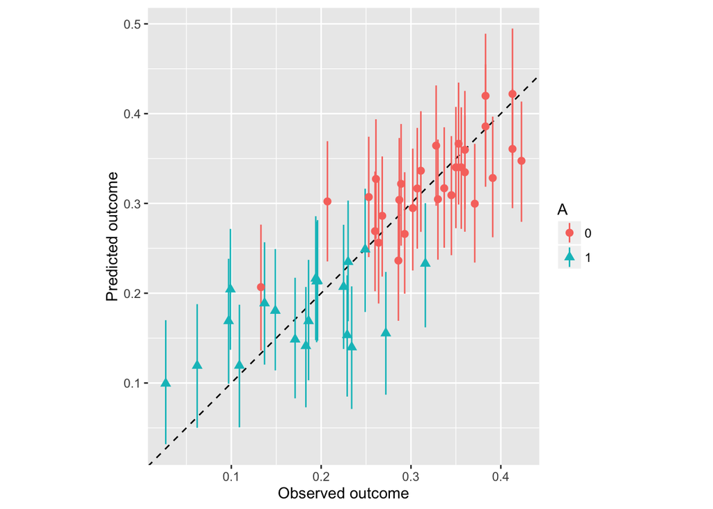

```r
p2 <- ggplot(d1, aes(x = Y, y = p50, ymin = p10, ymax = p90,
                     shape = A, color = A)) +
    geom_abline(intercept = 0, slope = 1, linetype = 'dashed') +
    geom_pointrange() +
    coord_fixed() +
    labs(x = 'Observed outcome', y = 'Predicted outcome')
print(p2)
```

## Q2. Binomial Model

```r
url <- getURL('https://raw.githubusercontent.com/MatsuuraKentaro/RStanBook/master/chap05/input/data-attendance-2.txt')
d2 <- read.csv(text = url)
glimpse(d2)
```

```
## Observations: 50
## Variables: 5
## $ PersonID <int> 1, 2, 3, 4, 5, 6, 7, 8, 9, 10, 11, 12, 13, 14, 15, 16...
## $ A        <int> 0, 1, 0, 1, 1, 0, 0, 1, 0, 0, 1, 0, 1, 0, 0, 1, 0, 0,...
## $ Score    <int> 69, 145, 125, 86, 158, 133, 111, 147, 146, 145, 141, ...
## $ M        <int> 43, 56, 32, 45, 33, 61, 49, 76, 78, 64, 34, 44, 53, 4...
## $ Y        <int> 38, 40, 24, 33, 23, 60, 35, 47, 63, 57, 18, 30, 33, 2...
```

First, try to understand the data by some visualiztion.

Then, here is a statistical model:
$$Y_n \sim \mbox{Binomial}(M_n, \theta_n),$$
$$\theta_n = \mathrm{logit}^{-1}(\beta_1 + \beta_2 A_n + \beta_3 Score_n),$$
$$\beta_1 \sim \mbox{Normal}(0, 10),$$
$$\beta_2 \sim \mbox{Normal}(0, 10),$$
$$\beta_3 \sim \mbox{Normal}(0, 10),$$
where $n = 1, 2, \dots, N$.

A Stan model.

```r
// d3-ex2.stan
data {
    int<lower=0> N;
    int<lower=0> M[N];
    int<lower=0> Y[N];
    int<lower=0, upper=1> A[N];
    real<lower=0, upper=1> S[N];
}

parameters {
    vector[3] b;
}

transformed parameters {
    vector<lower=0, upper=1>[N] theta;
    for (n in 1:N)
        theta[n] = inv_logit(b[1] + b[2]*A[n] + b[3]*S[n]);
}

model {
    Y ~ binomial(M, theta);
    b ~ normal(0, 10);
}

generated quantities {
    int<lower=0> y_pred[N];
    vector[N] log_lik;
    for (n in 1:N) {
        y_pred[n] = binomial_rng(M[n], theta[n]);
        log_lik[n] = binomial_lpmf(Y[n] | M[n], theta[n]);
    }
}
```

Compile.

```r
stan_ex2 <- stan_model('stan-models/d3-ex2.stan')
```

Sample.

```r
myd <- list(N = nrow(d2), M = d2$M, Y = d2$Y, A = d2$A, S = d2$Score/200)
fit_ex2 <- sampling(stan_ex2, data = myd, seed = 98765,
                    chains = 4, iter = 3000, warmup = 1500)
```

Look at the result.

```r
print(fit_ex2)
```

```
## Inference for Stan model: d3-ex2.
## 4 chains, each with iter=3000; warmup=1500; thin=1;
## post-warmup draws per chain=1500, total post-warmup draws=6000.
##
##                 mean se_mean   sd     2.5%      25%      50%      75%
## b[1]            0.10    0.01 0.23    -0.35    -0.06     0.10     0.26
## b[2]           -0.62    0.00 0.09    -0.80    -0.68    -0.62    -0.56
## b[3]            1.89    0.01 0.37     1.16     1.64     1.89     2.15
## theta[1]        0.68    0.00 0.02     0.63     0.66     0.68     0.70
## theta[2]        0.70    0.00 0.02     0.67     0.69     0.70     0.71
## theta[3]        0.78    0.00 0.01     0.76     0.77     0.78     0.79
## theta[4]        0.57    0.00 0.02     0.53     0.56     0.57     0.59
## theta[5]        0.73    0.00 0.02     0.69     0.71     0.73     0.74
## theta[6]        0.79    0.00 0.01     0.77     0.79     0.79     0.80
## theta[7]        0.76    0.00 0.01     0.73     0.75     0.76     0.77
## theta[8]        0.70    0.00 0.02     0.67     0.69     0.70     0.72
## theta[9]        0.81    0.00 0.01     0.79     0.81     0.81     0.82
## theta[10]       0.81    0.00 0.01     0.79     0.80     0.81     0.82
## theta[11]       0.69    0.00 0.02     0.66     0.68     0.69     0.70
## theta[12]       0.80    0.00 0.01     0.78     0.79     0.80     0.81
## theta[13]       0.64    0.00 0.01     0.62     0.63     0.64     0.65
## theta[14]       0.76    0.00 0.01     0.73     0.75     0.76     0.77
## theta[15]       0.76    0.00 0.01     0.73     0.75     0.76     0.76
## theta[16]       0.60    0.00 0.02     0.57     0.59     0.60     0.61
## theta[17]       0.76    0.00 0.01     0.74     0.76     0.76     0.77
## theta[18]       0.71    0.00 0.02     0.66     0.69     0.71     0.72
## theta[19]       0.86    0.00 0.02     0.83     0.85     0.86     0.87
## theta[20]       0.72    0.00 0.02     0.69     0.71     0.72     0.73
## theta[21]       0.57    0.00 0.02     0.53     0.56     0.57     0.59
## theta[22]       0.62    0.00 0.02     0.59     0.61     0.62     0.63
## theta[23]       0.62    0.00 0.02     0.59     0.61     0.62     0.63
## theta[24]       0.70    0.00 0.02     0.67     0.69     0.70     0.71
## theta[25]       0.64    0.00 0.01     0.61     0.63     0.64     0.65
## theta[26]       0.67    0.00 0.01     0.64     0.66     0.67     0.68
## theta[27]       0.77    0.00 0.01     0.75     0.76     0.77     0.78
## theta[28]       0.77    0.00 0.01     0.75     0.76     0.77     0.78
## theta[29]       0.83    0.00 0.01     0.81     0.83     0.83     0.84
## theta[30]       0.76    0.00 0.01     0.74     0.75     0.76     0.77
## theta[31]       0.74    0.00 0.02     0.70     0.73     0.74     0.75
## theta[32]       0.54    0.00 0.03     0.49     0.53     0.54     0.56
```

[output cut: 264 more lines]

```
## log_lik[42]    -1.73  3161    1
## log_lik[43]    -2.91  3540    1
## log_lik[44]    -1.80  2806    1
## log_lik[45]    -1.66  1870    1
## log_lik[46]    -2.51  2737    1
## log_lik[47]    -2.42  1677    1
## log_lik[48]    -1.99  2710    1
## log_lik[49]    -2.21  2371    1
## log_lik[50]    -2.30  2615    1
## lp__        -1387.97  1716    1
##
## Samples were drawn using NUTS(diag_e) at Tue Nov 22 15:06:32 2016.
## For each parameter, n_eff is a crude measure of effective sample size,
## and Rhat is the potential scale reduction factor on split chains (at
## convergence, Rhat=1).
```

(You should check the convergence by traceplots.)

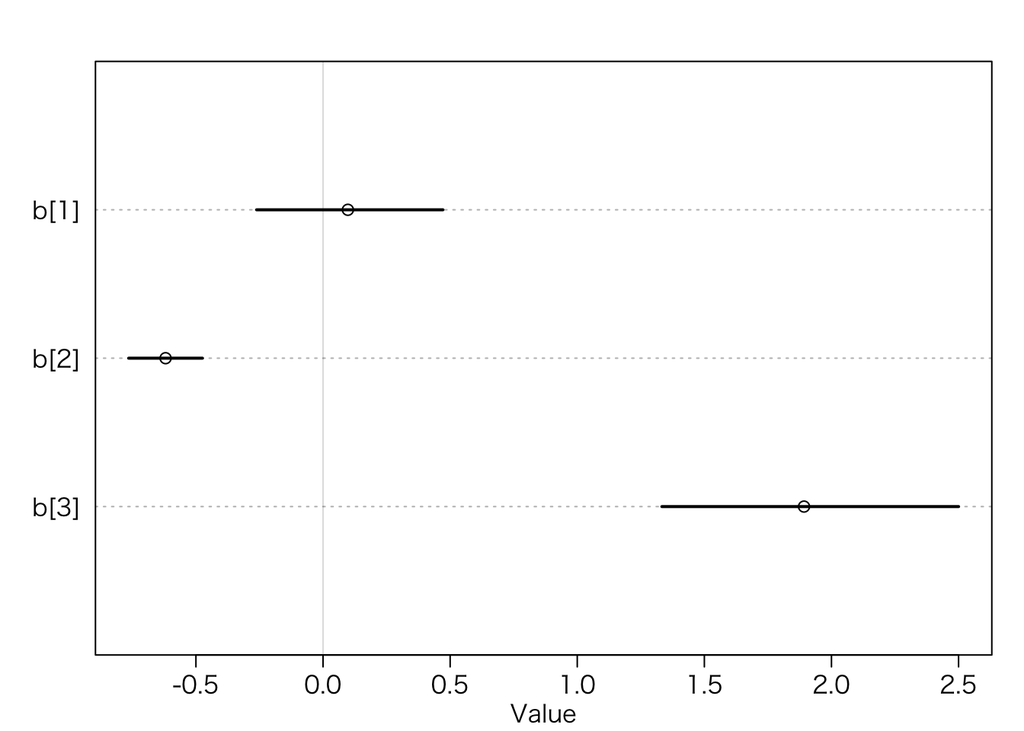

```r
plot(precis(fit_ex2, pars = 'b', depth = 2))
```

```r
# Or
#plot(fit_ex2, pars = 'b')
```

Plot predicted vs. observed.

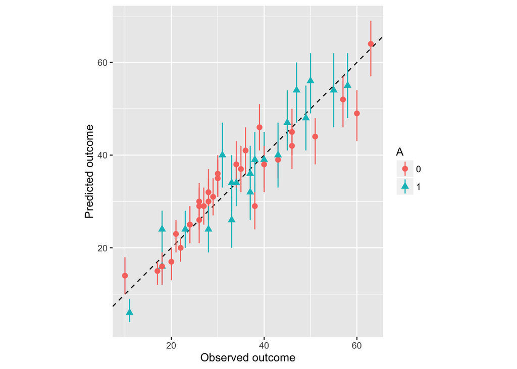

```r
mcsample <- rstan::extract(fit_ex2)
d_quant <- data.frame(p5 = apply(mcsample$y_pred, 2, quantile, .05),
                      p50 = apply(mcsample$y_pred, 2, quantile, .5),
                      p95 = apply(mcsample$y_pred, 2, quantile, .95))
d2 <- bind_cols(d2, d_quant) %>%
    mutate(A = as.factor(A))
p1 <- ggplot(d2, aes(x = Y, y = p50, ymin = p5, ymax = p95,
                     color = A, shape = A)) +
    geom_abline(intercept = 0, slope = 1, linetype = 'dashed') +
    geom_pointrange() +
    coord_fixed() +
    labs(x = 'Observed outcome', y = 'Predicted outcome')
print(p1)
```

Predicted rate vs. observed rate.

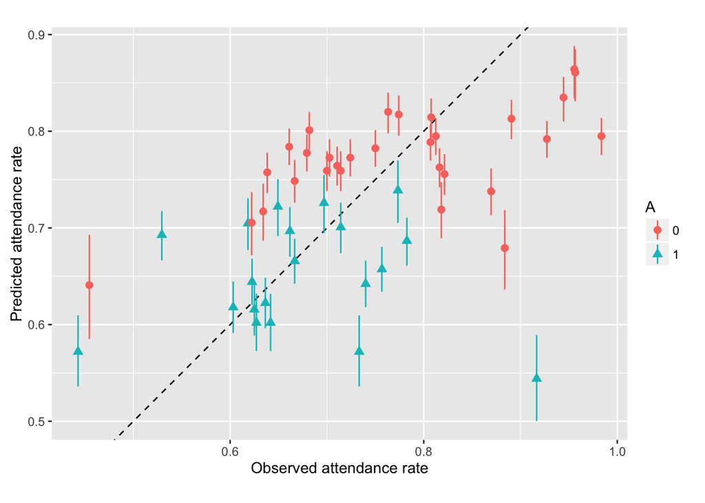

```r
d_quant <- data.frame(rate_p5 = apply(mcsample$theta, 2, quantile, .05),
                      rate_p50 = apply(mcsample$theta, 2, quantile, .5),
                      rate_p95 = apply(mcsample$theta, 2, quantile, .95))
d2 <- bind_cols(d2, d_quant) %>%
    mutate(rate = Y/M)
p2 <- ggplot(d2, aes(x = rate, y = rate_p50, ymin = rate_p5, ymax = rate_p95,
                     color = A, shape = A)) +
    geom_abline(intercept = 0, slope = 1, linetype = 'dashed') +
    geom_pointrange() +
    coord_fixed() +
    labs(x = 'Observed attendance rate', y = 'Predicted attendance rate')
print(p2)
```

## Q3. Bernoulli Model

```r
url <- getURL('https://raw.githubusercontent.com/MatsuuraKentaro/RStanBook/master/chap05/input/data-attendance-3.txt')
d3 <- read.csv(text = url)
glimpse(d3)
```

```
## Observations: 2,396
## Variables: 5
## $ PersonID <int> 1, 1, 1, 1, 1, 1, 1, 1, 1, 1, 1, 1, 1, 1, 1, 1, 1, 1,...
## $ A        <int> 0, 0, 0, 0, 0, 0, 0, 0, 0, 0, 0, 0, 0, 0, 0, 0, 0, 0,...
## $ Score    <int> 69, 69, 69, 69, 69, 69, 69, 69, 69, 69, 69, 69, 69, 6...
## $ Weather  <fctr> B, A, C, A, B, B, C, B, A, A, A, C, A, A, A, A, A, B...
## $ Y        <int> 1, 1, 1, 1, 1, 1, 0, 1, 1, 1, 1, 1, 1, 1, 1, 1, 0, 1,...
```

Before building a model, try to understand the data. Let’s change the labels of Weather.

```r
d3 <- d3 %>%
    mutate(Weather = factor(Weather, labels = c('clear', 'cloudy', 'rainy')))
```

A statistical model.
$$Y_i \sim \mbox{Bernoulli}(theta_i),$$
$$theta_i = \mathrm{logit}^{-1}(\beta_1 + \beta_2 A_i + \beta_3 Score_i + \beta_4 Weather_i),$$
$$beta_k \sim \mbox{Normal}(0, 10),$$
where $i = 1, 2, \dots, I$ and $k = 1, 2, 3, 4$.

A Stan model.

```r
// d3-ex3.stan
data {
    int<lower=0> I;
    int<lower=0, upper=1> Y[I];
    int<lower=0, upper=1> A[I];
    real<lower=0, upper=1> S[I];
    real<lower=0, upper=1> W[I];
}

parameters {
    vector[4] b;
}

transformed parameters {
    vector<lower=0, upper=1>[I] theta;
    for (i in 1:I)
        theta[i] = inv_logit(b[1] + b[2]*A[i] + b[3]*S[i] + b[4]*W[i]);
}

model {
    Y ~ bernoulli(theta);
    b ~ normal(0, 10);
}

generated quantities {
    vector[I] log_lik;
    for (i in 1:I)
        log_lik[i] = bernoulli_lpmf(Y[i] | theta[i]);
}
```

Compile.

```r
stan_ex3 <- stan_model('stan-models/d3-ex3.stan')
```

Sample after converting the Weather variable, which is originally categorical, into a numerical values.

```r
conv <- c(0, 0.2, 1)
names(conv) <- c('clear', 'cloudy', 'rainy')
myd <- list(I = nrow(d3), Y = d3$Y, A = d3$A, S = d3$Score/200, W = conv[d3$Weather])
fit_ex3 <- sampling(stan_ex3, data = myd, seed = 13579,
                    chains = 4, iter = 3000, warmup = 1500)
```

Look at the result.

```r
print(fit_ex3)
```

```
## Inference for Stan model: d3-ex3.
## 4 chains, each with iter=3000; warmup=1500; thin=1;
## post-warmup draws per chain=1500, total post-warmup draws=6000.
##
##                   mean se_mean   sd     2.5%      25%      50%      75%
## b[1]              0.16    0.00 0.23    -0.30     0.01     0.16     0.32
## b[2]             -0.62    0.00 0.09    -0.80    -0.68    -0.62    -0.56
## b[3]              1.97    0.01 0.37     1.25     1.73     1.96     2.21
## b[4]             -0.46    0.00 0.12    -0.70    -0.54    -0.46    -0.38
## theta[1]          0.68    0.00 0.02     0.63     0.66     0.68     0.70
## theta[2]          0.70    0.00 0.02     0.65     0.68     0.70     0.72
## theta[3]          0.59    0.00 0.04     0.52     0.57     0.59     0.62
## theta[4]          0.70    0.00 0.02     0.65     0.68     0.70     0.72
## theta[5]          0.68    0.00 0.02     0.63     0.66     0.68     0.70
## theta[6]          0.68    0.00 0.02     0.63     0.66     0.68     0.70
## theta[7]          0.59    0.00 0.04     0.52     0.57     0.59     0.62
## theta[8]          0.68    0.00 0.02     0.63     0.66     0.68     0.70
## theta[9]          0.70    0.00 0.02     0.65     0.68     0.70     0.72
## theta[10]         0.70    0.00 0.02     0.65     0.68     0.70     0.72
## theta[11]         0.70    0.00 0.02     0.65     0.68     0.70     0.72
## theta[12]         0.59    0.00 0.04     0.52     0.57     0.59     0.62
## theta[13]         0.70    0.00 0.02     0.65     0.68     0.70     0.72
## theta[14]         0.70    0.00 0.02     0.65     0.68     0.70     0.72
## theta[15]         0.70    0.00 0.02     0.65     0.68     0.70     0.72
## theta[16]         0.70    0.00 0.02     0.65     0.68     0.70     0.72
## theta[17]         0.70    0.00 0.02     0.65     0.68     0.70     0.72
## theta[18]         0.68    0.00 0.02     0.63     0.66     0.68     0.70
## theta[19]         0.70    0.00 0.02     0.65     0.68     0.70     0.72
## theta[20]         0.70    0.00 0.02     0.65     0.68     0.70     0.72
## theta[21]         0.68    0.00 0.02     0.63     0.66     0.68     0.70
## theta[22]         0.68    0.00 0.02     0.63     0.66     0.68     0.70
## theta[23]         0.59    0.00 0.04     0.52     0.57     0.59     0.62
## theta[24]         0.59    0.00 0.04     0.52     0.57     0.59     0.62
## theta[25]         0.70    0.00 0.02     0.65     0.68     0.70     0.72
## theta[26]         0.70    0.00 0.02     0.65     0.68     0.70     0.72
## theta[27]         0.68    0.00 0.02     0.63     0.66     0.68     0.70
## theta[28]         0.70    0.00 0.02     0.65     0.68     0.70     0.72
## theta[29]         0.68    0.00 0.02     0.63     0.66     0.68     0.70
## theta[30]         0.70    0.00 0.02     0.65     0.68     0.70     0.72
## theta[31]         0.68    0.00 0.02     0.63     0.66     0.68     0.70
```

[output cut: 9550 more lines]

```
## log_lik[2388]    -0.41  3851    1
## log_lik[2389]    -0.41  3851    1
## log_lik[2390]    -0.45  3911    1
## log_lik[2391]    -0.61  3852    1
## log_lik[2392]    -0.45  3911    1
## log_lik[2393]    -0.41  3851    1
## log_lik[2394]    -0.41  3851    1
## log_lik[2395]    -0.55  3865    1
## log_lik[2396]    -0.61  3852    1
## lp__          -1381.32  2290    1
##
## Samples were drawn using NUTS(diag_e) at Tue Nov 22 15:07:01 2016.
## For each parameter, n_eff is a crude measure of effective sample size,
## and Rhat is the potential scale reduction factor on split chains (at
## convergence, Rhat=1).
```

(You should examine the convergence by tracepolots.)

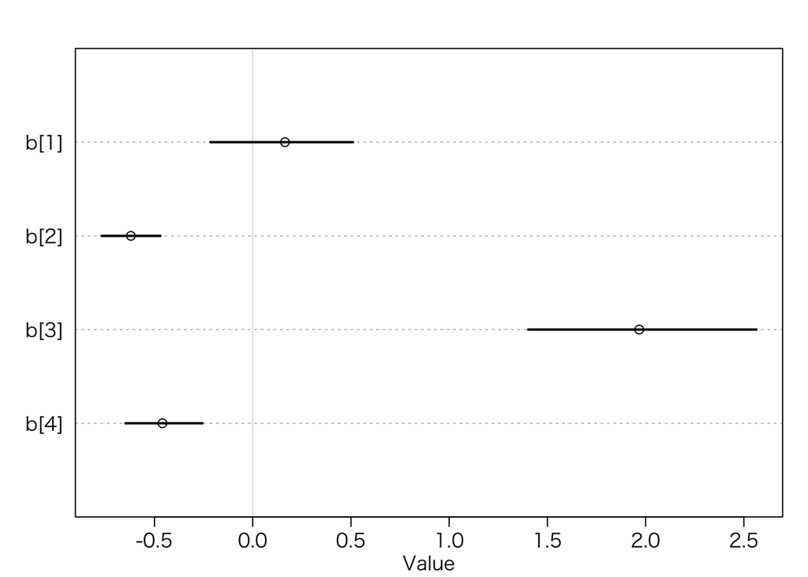

```r
plot(precis(fit_ex3, pars = 'b', depth = 2))
```

```r
# Or
# plot(fit_ex3, pars = 'b')
```

Evalute the fit.

```r
mcsample <- rstan::extract(fit_ex3)
d3 <- d3 %>% mutate(A = as.factor(A),
                    p5 = apply(mcsample$theta, 2, quantile, .05),
                    p50 = apply(mcsample$theta, 2, quantile, .5),
                    p95 = apply(mcsample$theta, 2, quantile, .95),
                    p_mean = apply(mcsample$theta, 2, mean))
# error rate
ert <- with(d3, mean((p_mean > 0.5 & Y == 0) | (p_mean < 0.5 & Y == 1)))
# hit rate
1 - ert
```

```
## [1] 0.7191152
```

```r
# baseline
max(mean(d3$Y), 1 - mean(d3$Y))
```

```
## [1] 0.7186978
```

Visualize the predicted probability of outcome being one.

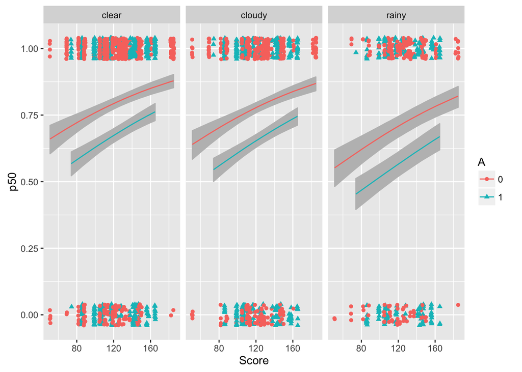

```r
p1 <- ggplot(d3, aes(x = Score, color = A, shape = A)) +
    geom_ribbon(aes(ymin = p5, ymax = p95), fill = 'gray', color = 'gray') +
    geom_line(aes(y = p50)) +
    facet_wrap(~ Weather) +
    geom_point(aes(y = Y), position = position_jitter(height = .1))
print(p1)
```

Violin plot of observed outcome vs. predicted probability.

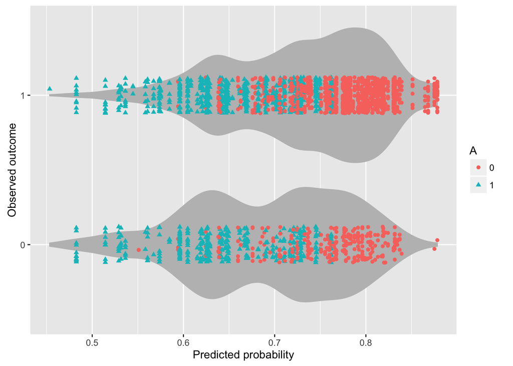

```r
p2 <- ggplot(d3, aes(x = as.factor(Y), y = p_mean)) +
    geom_violin(trim = FALSE, color = 'gray', fill = 'gray') +
    geom_point(aes(color = A, shape = A),
               position = position_jitter(width = .3)) +
    labs(y = 'Predicted probability', x = 'Observed outcome') +
    coord_flip()
print(p2)
```

ROC curve with uncertainty. Reuse the function we used in Introduction to GLM.

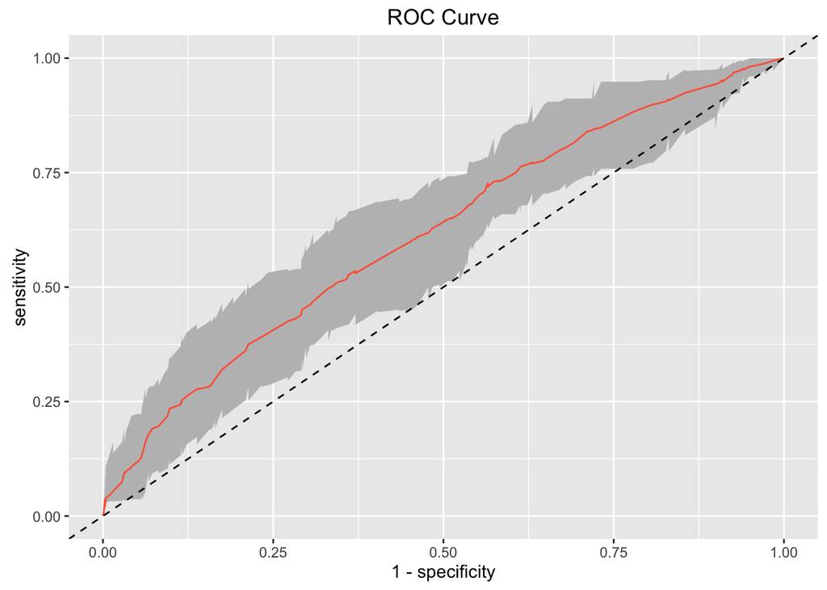

```r
## Function to calculate the true positive rate (sensitivity)
true_pos <- function(predicted, observed, cutoff = .5) {
    n <- length(cutoff)
    res <- rep(NA, n)
    for (i in 1:n) {
        cond_met <- predicted >= cutoff[i] & observed == 1
        res[i] <- mean(cond_met) / mean(observed)
    }
    return(res)
}
## Function to calculate the false positive rate（1- specificity)
false_pos <- function(predicted, observed, cutoff = .5) {
    n <- length(cutoff)
    res <- rep(NA, n)
    for (i in 1:n) {
        cond_met <- predicted >= cutoff[i] & observed == 0
        res[i] <- mean(cond_met) / (1 - mean(observed))
    }
    return(res)
}

## Get TPRs and FPRs by changing the cutoff from 0 to 1
cutoff_vec <- seq(0, 1, length = 1000)
tp_mean <- true_pos(d3$p_mean, d3$Y, cutoff = cutoff_vec)
tp_lb <- true_pos(d3$p5, d3$Y, cutoff = cutoff_vec)
tp_ub <- true_pos(d3$p95, d3$Y, cutoff = cutoff_vec)
fp_mean <- false_pos(d3$p_mean, d3$Y, cutoff = cutoff_vec)
df <- data.frame(tp = tp_mean, lb = tp_lb, ub = tp_ub, fp = fp_mean)
roc <- ggplot(df, aes(x = fp_mean, y = tp_mean, ymin = lb, ymax = ub)) +
    geom_ribbon(fill = 'gray') +
    geom_line(color = 'tomato') +
    geom_abline(intercept = 0, slope = 1, linetype = 'dashed') +
    labs(x = '1 - specificity', y = 'sensitivity', title = 'ROC Curve')
print(roc)
```

Posterior distribution of parameters.

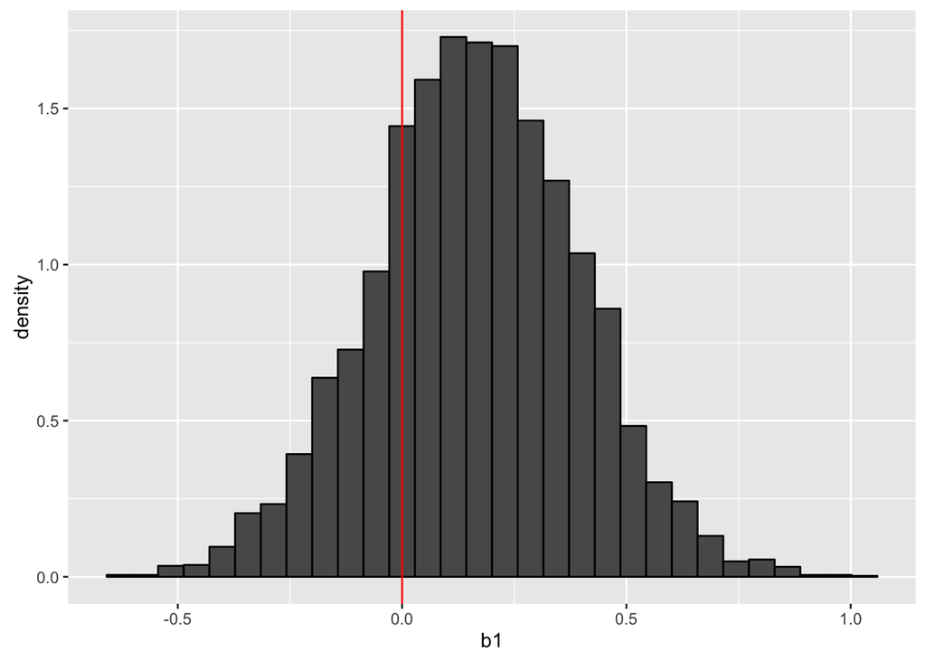

```r
df <- data.frame(mcsample$b)
names(df) <- paste0('b', 1:4)
hist1 <- ggplot(df, aes(y = ..density..)) +
    geom_histogram(aes(x = b1), color = 'black') +
    geom_vline(xintercept = 0, color = 'red')
print(hist1)
```

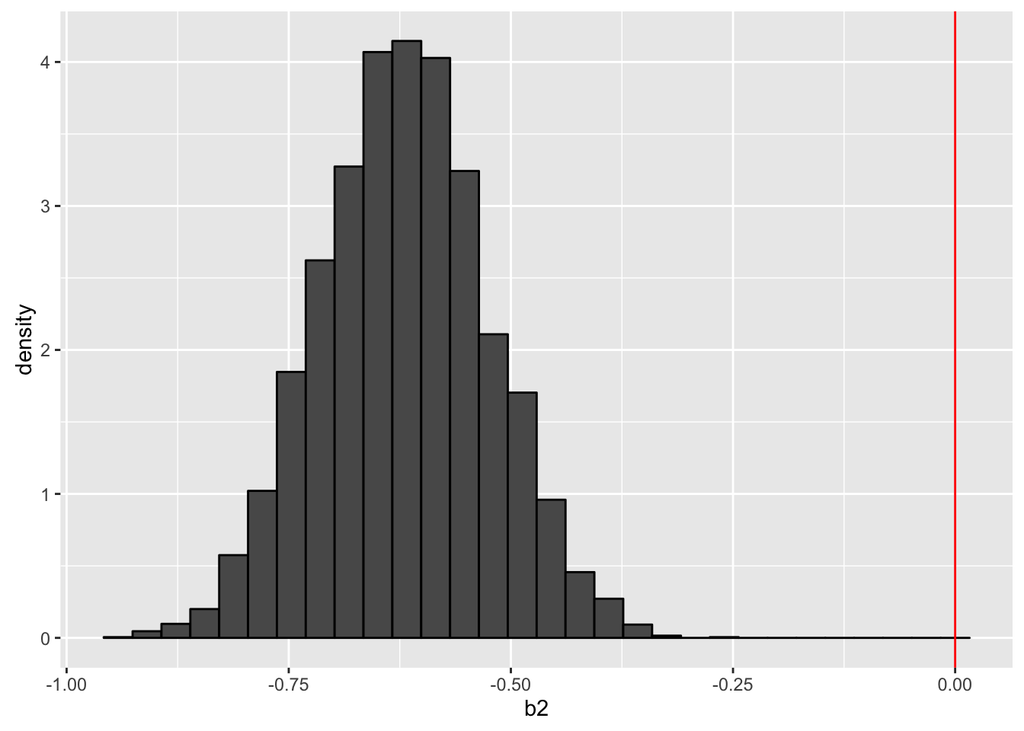

```r
hist2 <- ggplot(df, aes(y = ..density..)) +
    geom_histogram(aes(x = b2), color = 'black') +
    geom_vline(xintercept = 0, color = 'red')
print(hist2)
```

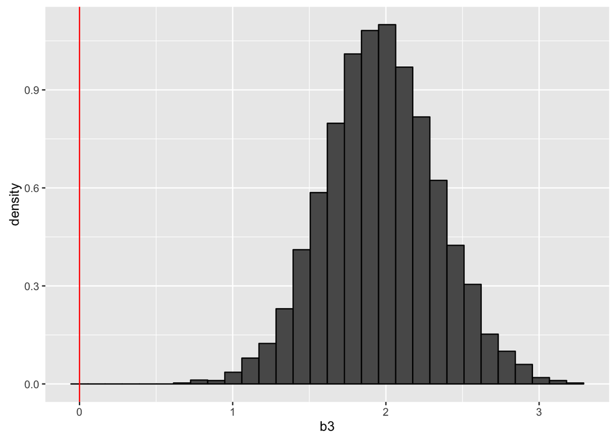

```r
hist3 <- ggplot(df, aes(y = ..density..)) +
    geom_histogram(aes(x = b3), color = 'black') +
    geom_vline(xintercept = 0, color = 'red')
print(hist3)
```

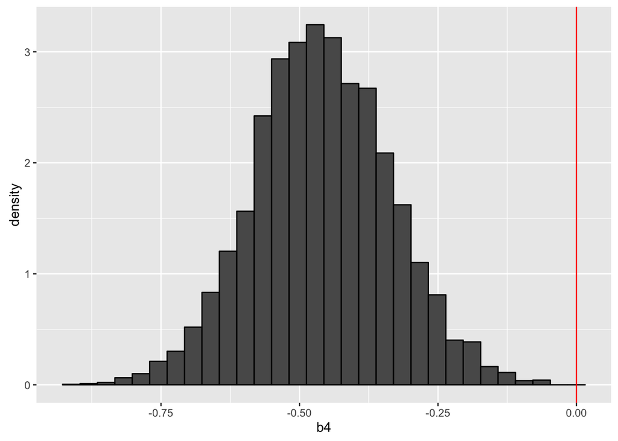

```r
hist4 <- ggplot(df, aes(y = ..density..)) +
    geom_histogram(aes(x = b4), color = 'black') +
    geom_vline(xintercept = 0, color = 'red')
print(hist4)
```

```r
sum(df$b3 > 1) / nrow(df)
```

```
## [1] 0.9955
```

So the probability is larger than .99, which implies that the effect of Score on attendance is surely positive. However, as we have seen above, Score cannot distinguish the outcome well. So, the fact that the effect exists (or thta it is significant in frequentist sense) does not imply the substantive significance of the variable.

Back to Class Materials